# Sağlık Sigortası Masraflarının Doğrusal Regresyon ile Modellenmesi

Regresyon varsayımları, model tanıları ve model karşılaştırması

Mehmet Hamza

10.11.2026

# 1 Amaç

Bu çalışmada bir sağlık sigortası şirketinin müşterilerine ait 1338 gözlemlik bir veri seti üzerinde **yıllık sigorta masrafı** (`charges`) yaş, BMI, çocuk sayısı, sigara kullanımı, cinsiyet ve bölge ile nasıl açıklanır sorusu **çoklu doğrusal regresyon** ile yanıtlanır. Aynı verinin lojistik regresyon ile analizi ayrı bir depodadır (`health-insurance-logistic-regression`).

Analiz şu akışı izler: veri inceleme → eğitim/test ayırma → model kurma → varsayım kontrolleri → sorun çıkınca dönüşüm / değişken seçimi / etkileşim terimi / aykırı gözlem analizi / ağırlıklı en küçük kareler → test verisinde performans ve çapraz doğrulama.

# 2 Veri

```r
d <- read.csv("data/insurance.csv", stringsAsFactors = TRUE)
d$smoker <- relevel(d$smoker, ref = "no")
str(d)
```

```
## 'data.frame':    1338 obs. of  7 variables:
##  $ age     : int  19 18 28 33 32 31 46 37 37 60 ...
##  $ sex     : Factor w/ 2 levels "female","male": 1 2 2 2 2 1 1 1 2 1 ...
##  $ bmi     : num  27.9 33.8 33 22.7 28.9 ...
##  $ children: int  0 1 3 0 0 0 1 3 2 0 ...
##  $ smoker  : Factor w/ 2 levels "no","yes": 2 1 1 1 1 1 1 1 1 1 ...
##  $ region  : Factor w/ 4 levels "northeast","northwest",..: 4 3 3 2 2 3 3 2 1 2 ...
##  $ charges : num  16885 1726 4449 21984 3867 ...
```

```r
summary(d)
```

```
##       age            sex           bmi           children     smoker
##  Min.   :18.00   female:662   Min.   :15.96   Min.   :0.000   no :1064
##  1st Qu.:27.00   male  :676   1st Qu.:26.30   1st Qu.:0.000   yes: 274
##  Median :39.00                Median :30.40   Median :1.000
##  Mean   :39.21                Mean   :30.66   Mean   :1.095
##  3rd Qu.:51.00                3rd Qu.:34.69   3rd Qu.:2.000
##  Max.   :64.00                Max.   :53.13   Max.   :5.000
##        region       charges
##  northeast:324   Min.   : 1122
##  northwest:325   1st Qu.: 4740
##  southeast:364   Median : 9382
##  southwest:325   Mean   :13270
##                  3rd Qu.:16640
##                  Max.   :63770
```

```r
cat("Eksik gözlem sayısı:", sum(is.na(d)), "\n")
```

```
## Eksik gözlem sayısı: 0
```

| Değişken | Tür | Açıklama |
| --- | --- | --- |
| `charges` | sürekli (**Y**) | Yıllık sağlık sigortası masrafı |
| `age` | sürekli | Yaş |
| `bmi` | sürekli | Vücut kitle indeksi |
| `children` | sayım | Çocuk sayısı |
| `smoker` | nitel (2 düzey) | Sigara kullanımı |
| `sex` | nitel (2 düzey) | Cinsiyet |
| `region` | nitel (4 düzey) | Bölge |

> **Veri kaynağı ve uyarı:** `insurance.csv`, Brett Lantz’ın *Machine Learning with R* kitabı ile ilişkilendirilen ve Kaggle’da da bulunan açık bir eğitim veri setidir. Bu çalışmada GitHub’daki `stedy/Machine-Learning-with-R-datasets` deposundaki kopyası kullanılmıştır. Verinin ilk kaynağı ve lisansı doğrulanmamıştır; **gerçek bir şirket verisi olduğuna dair belge yoktur ve büyük olasılıkla simüle edilmiştir.** Bu nedenle bulgular gerçek bir sigorta portföyüne genellenmemeli, bir eğitim uygulaması olarak değerlendirilmelidir.

**Nitel değişkenler ve kukla (dummy) değişkenler.** `smoker` ve `sex` iki düzeyli olduğundan 1’er, `region` dört düzeyli olduğundan 3 kukla değişken oluşur (n−1 kuralı). R, faktör değişkenleri `lm` içinde otomatik olarak kukla değişkene çevirir; referans düzeyler `smoker = no`, `sex = female`, `region = northeast`’tir.

```r
head(model.matrix(charges ~ ., data = d), 4)
```

```
##   (Intercept) age sexmale    bmi children smokeryes regionnorthwest
## 1           1  19       0 27.900        0         1               0
## 2           1  18       1 33.770        1         0               0
## 3           1  28       1 33.000        3         0               0
## 4           1  33       1 22.705        0         0               1
##   regionsoutheast regionsouthwest
## 1               0               1
## 2               1               0
## 3               1               0
## 4               0               0
```

# 3 Ön İnceleme

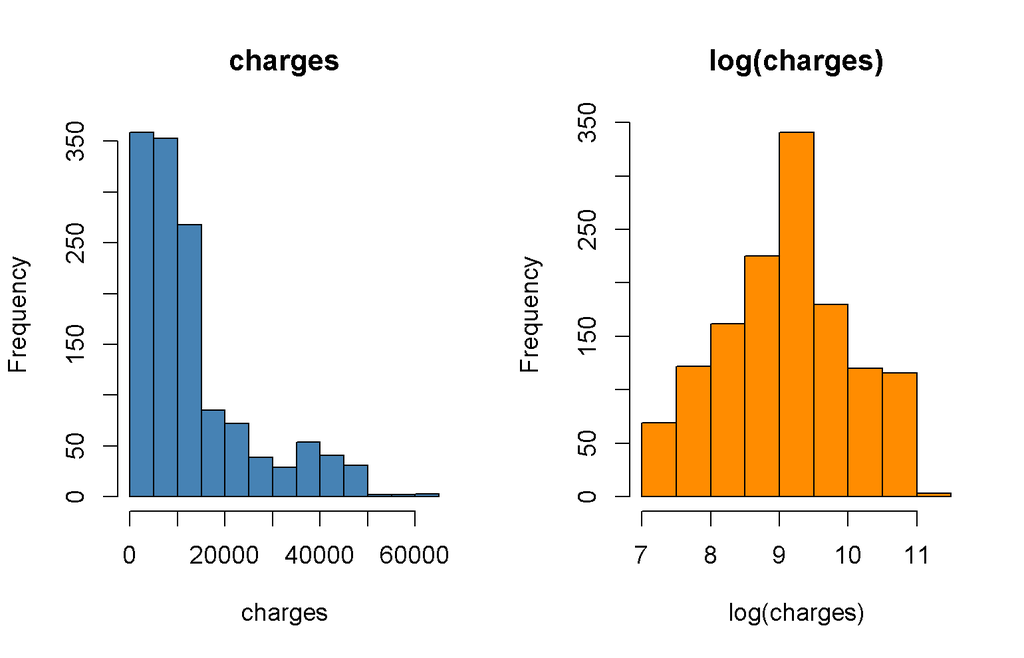

```r
par(mfrow = c(1, 2))
hist(d$charges, main = "charges", xlab = "charges", col = "steelblue")
hist(log(d$charges), main = "log(charges)", xlab = "log(charges)", col = "darkorange")
```

```r
par(mfrow = c(1, 1))
```

`charges` belirgin biçimde sağa çarpıktır; logaritma dönüşümü dağılımı simetriğe yaklaştırır. Bu durum normallik ve sabit varyans varsayımları için önemli olacaktır.

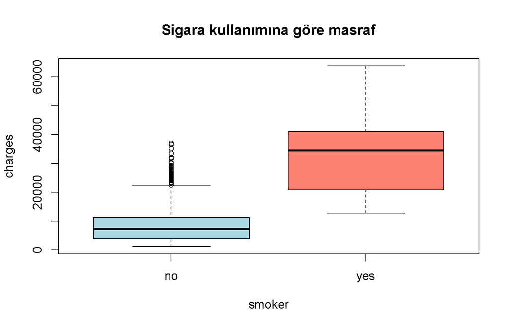

```r
boxplot(charges ~ smoker, data = d, col = c("lightblue", "salmon"),
        main = "Sigara kullanımına göre masraf", xlab = "smoker", ylab = "charges")
```

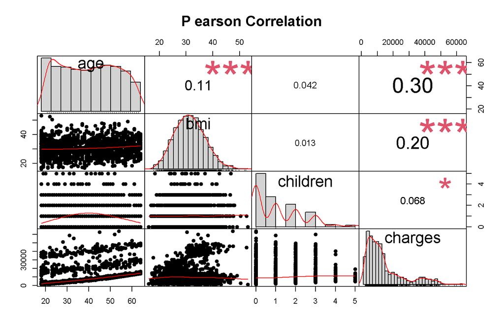

```r
chart.Correlation(d[, c("age", "bmi", "children", "charges")], histogram = TRUE, pch = 19)
```

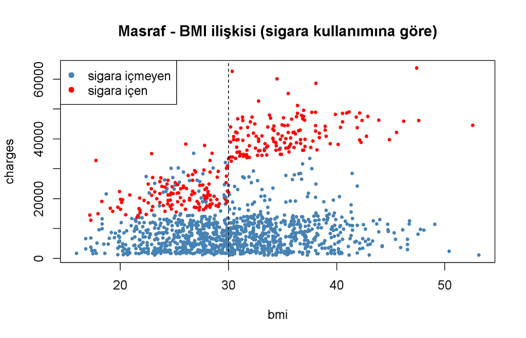

```r
renk <- ifelse(d$smoker == "yes", "red", "steelblue")
plot(d$bmi, d$charges, col = renk, pch = 19, cex = 0.6,
     main = "Masraf - BMI ilişkisi (sigara kullanımına göre)", xlab = "bmi", ylab = "charges")
abline(v = 30, lty = 2)
legend("topleft", c("sigara içmeyen", "sigara içen"), col = c("steelblue", "red"), pch = 19)
```

Sigara içenler ayrı bir küme oluşturur ve **içenlerde BMI ≈ 30’dan sonra masraf belirgin biçimde sıçrar**; içmeyenlerde böyle bir kırılma görülmez. Yani BMI’nin etkisi sigara kullanımına göre değişiyor gibidir. Bu, ilerleyen bölümlerde bir **etkileşim terimi** ile sınanacaktır.

Sigara içenlerin masrafı belirgin biçimde yüksektir. Sayısal bağımsız değişkenler arasındaki korelasyonlar düşüktür; çoklu bağlantı beklenmez (VIF ile doğrulanacaktır).

# 4 Eğitim / Test Ayırma

Veri %80 eğitim, %20 test olarak bölünmüştür (`set.seed(145)`).

```r
set.seed(145)
sampleindx <- sample(1:nrow(d), size = 0.8 * nrow(d))
trainset <- d[sampleindx, ]
testset  <- d[-sampleindx, ]
c(egitim = nrow(trainset), test = nrow(testset))
```

```
## egitim   test
##   1070    268
```

# 5 Doğrusal Regresyon

## 5.1 Başlangıç modeli (tüm değişkenlerle)

```r
model1 <- lm(charges ~ ., data = trainset)
summary(model1)
```

```
##
## Call:
## lm(formula = charges ~ ., data = trainset)
##
## Residuals:
##      Min       1Q   Median       3Q      Max
## -11042.9  -2762.4   -847.2   1332.2  25944.7
##
## Coefficients:
##                   Estimate Std. Error t value             Pr(>|t|)
## (Intercept)     -12392.959   1057.582 -11.718 < 0.0000000000000002 ***
## age                263.996     12.802  20.622 < 0.0000000000000002 ***
## sexmale            -75.009    357.784  -0.210              0.83398
## bmi                331.190     30.483  10.865 < 0.0000000000000002 ***
## children           469.982    149.108   3.152              0.00167 **
## smokeryes        23748.810    448.020  53.008 < 0.0000000000000002 ***
## regionnorthwest      9.984    507.536   0.020              0.98431
## regionsoutheast   -645.795    510.743  -1.264              0.20636
## regionsouthwest   -551.467    513.830  -1.073              0.28340
## ---
## Signif. codes:  0 '***' 0.001 '**' 0.01 '*' 0.05 '.' 0.1 ' ' 1
##
## Residual standard error: 5832 on 1061 degrees of freedom
## Multiple R-squared:  0.7642, Adjusted R-squared:  0.7624
## F-statistic: 429.9 on 8 and 1061 DF,  p-value: < 0.00000000000000022
```

**Yorum.** Model bütün olarak anlamlıdır (F testi p < 0,001) ve düzeltilmiş R² ≈ 0,76’dır. `age`, `bmi`, `children` ve `smoker` katsayıları anlamlıdır; `sex` ve `region` düzeyleri anlamsızdır (p > 0,05). Diğer değişkenler sabitken sigara içenlerin masrafı ortalama ≈ 23.750 birim yüksektir, yaşın her yılı ≈ 264, BMI’nin her birimi ≈ 331 birim ekler. Ancak bu t-testlerine güvenebilmek için varsayımların sağlanması gerekir.

## 5.2 Varsayım kontrolleri

### 5.2.1 Normallik

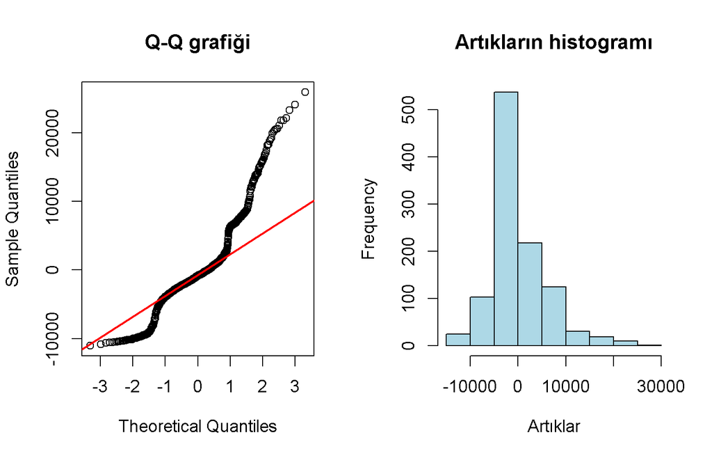

```r
artiklar <- residuals(model1)
par(mfrow = c(1, 2))
qqnorm(artiklar, main = "Q-Q grafiği"); qqline(artiklar, col = "red", lwd = 2)
hist(artiklar, main = "Artıkların histogramı", xlab = "Artıklar", col = "lightblue")
```

```r
par(mfrow = c(1, 1))
shapiro.test(artiklar)
```

```
##
##  Shapiro-Wilk normality test
##
## data:  artiklar
## W = 0.90372, p-value < 0.00000000000000022
```

```r
lillie.test(artiklar)
```

```
##
##  Lilliefors (Kolmogorov-Smirnov) normality test
##
## data:  artiklar
## D = 0.16136, p-value < 0.00000000000000022
```

```r
ad.test(artiklar)
```

```
##
##  Anderson-Darling normality test
##
## data:  artiklar
## A = 35.257, p-value < 0.00000000000000022
```

**Hipotezler:** H0: artıklar normal dağılır; H1: normallikten sapar. Üç testin (Shapiro-Wilk W ≈ 0,90; Lilliefors D ≈ 0,16; Anderson-Darling A ≈ 35) p-değerleri de 0,05’ten çok küçüktür; **H0 reddedilir, artıklar normal dağılmaz.** Q-Q grafiğinde özellikle sağ uçta çizgiden belirgin sapma vardır.

### 5.2.2 Sabit varyans

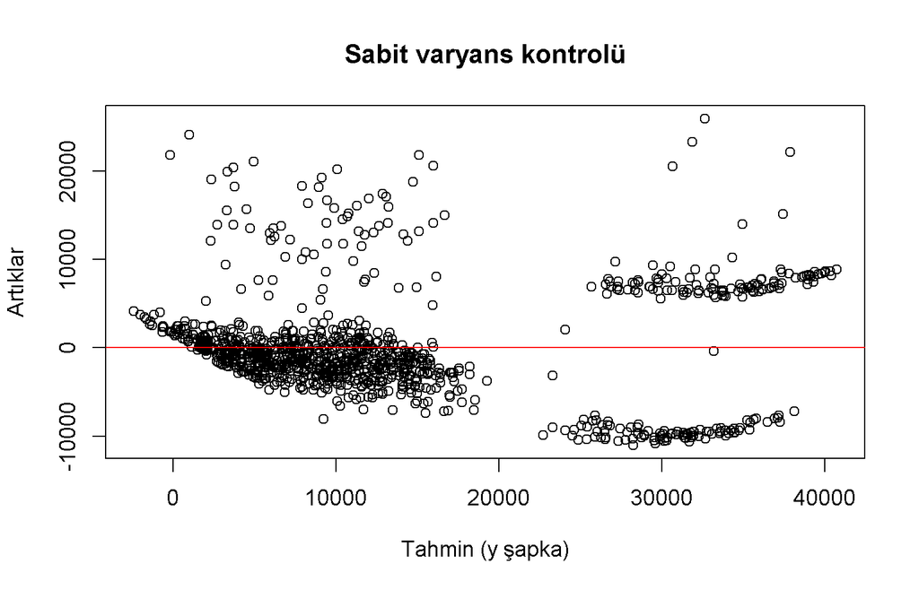

```r
plot(fitted(model1), residuals(model1), main = "Sabit varyans kontrolü",
     xlab = "Tahmin (y şapka)", ylab = "Artıklar")
abline(h = 0, col = "red")
```

```r
# Breusch-Pagan testi (H0: varyans sabittir)
bptest(model1)
```

```
##
##  studentized Breusch-Pagan test
##
## data:  model1
## BP = 120.92, df = 8, p-value < 0.00000000000000022
```

```r
# White testi (elle): artık karelerini fitted ve fitted^2 üzerine regresle
kare_artiklar <- residuals(model1)^2
f <- fitted(model1)
white <- lm(kare_artiklar ~ f + I(f^2))
summary(white)   # F testinin p-değeri H0 (sabit varyans) için karar verir
```

```
##
## Call:
## lm(formula = kare_artiklar ~ f + I(f^2))
##
## Residuals:
##       Min        1Q    Median        3Q       Max
## -77433480 -23599916 -16359501  -8739501 597131975
##
## Coefficients:
##                   Estimate     Std. Error t value Pr(>|t|)
## (Intercept) 12644161.30826  5355743.78424   2.361   0.0184 *
## f                960.09215      773.16931   1.242   0.2146
## I(f^2)             0.03009        0.01987   1.514   0.1303
## ---
## Signif. codes:  0 '***' 0.001 '**' 0.01 '*' 0.05 '.' 0.1 ' ' 1
##
## Residual standard error: 67160000 on 1067 degrees of freedom
## Multiple R-squared:  0.09792,    Adjusted R-squared:  0.09623
## F-statistic: 57.91 on 2 and 1067 DF,  p-value: < 0.00000000000000022
```

Breusch-Pagan testi (BP ≈ 121, p < 0,001) ve elle yapılan White testinin F testi (p ≈ 10⁻²⁴) H0’ı reddeder: **varyans sabit değildir.** Artık–tahmin grafiği de bunu gösterir; üstelik düzgün bir huni yerine **birbirinden ayrışmış artık kümeleri** görülür. Bu, modelde sigara içenler ile içmeyenler arasında açıklanamayan bir yapı kaldığına işaret eder.

### 5.2.3 Otokorelasyon ve çoklu bağlantı

```r
dwtest(model1)   # H0: otokorelasyon yoktur
```

```
##
##  Durbin-Watson test
##
## data:  model1
## DW = 1.9543, p-value = 0.2265
## alternative hypothesis: true autocorrelation is greater than 0
```

```r
vif(model1)      # 10'dan büyük ise müdahale gerekir
```

```
##              GVIF Df GVIF^(1/(2*Df))
## age      1.017100  1        1.008514
## sex      1.006471  1        1.003230
## bmi      1.097589  1        1.047659
## children 1.004480  1        1.002237
## smoker   1.010381  1        1.005177
## region   1.092154  3        1.014800
```

Durbin-Watson istatistiği ≈ 1,95 (1,5–2,5 arası), p ≈ 0,23: **otokorelasyon yoktur** (veri zaman serisi de değildir). Tüm VIF değerleri ≈ 1’dir (en büyüğü ≈ 1,10): **çoklu bağlantı sorunu yoktur.**

**Özet:** Çoklu bağlantı ve otokorelasyon sorunu yok; fakat **normallik ve sabit varyans varsayımları sağlanmıyor.** Bu durumda ilk akla gelen çözüm bağımlı değişkene log dönüşümüdür.

## 5.3 Çözüm 1: Bağımlı değişkene log dönüşümü

Değişen varyans ve normallik sapması durumunda ilk akla gelen çözüm bağımlı değişkene **logaritmik dönüşüm** uygulamaktır.

```r
model2 <- lm(log(charges) ~ ., data = trainset)
summary(model2)
```

```
##
## Call:
## lm(formula = log(charges) ~ ., data = trainset)
##
## Residuals:
##      Min       1Q   Median       3Q      Max
## -1.02612 -0.18173 -0.04391  0.06257  2.15206
##
## Coefficients:
##                   Estimate Std. Error t value             Pr(>|t|)
## (Intercept)      6.9374869  0.0764519  90.743 < 0.0000000000000002 ***
## age              0.0360498  0.0009254  38.954 < 0.0000000000000002 ***
## sexmale         -0.0749919  0.0258640  -2.899             0.003815 **
## bmi              0.0133264  0.0022036   6.048        0.00000000203 ***
## children         0.1019422  0.0107789   9.458 < 0.0000000000000002 ***
## smokeryes        1.5375425  0.0323871  47.474 < 0.0000000000000002 ***
## regionnorthwest -0.0235825  0.0366895  -0.643             0.520520
## regionsoutheast -0.1341511  0.0369213  -3.633             0.000293 ***
## regionsouthwest -0.0943127  0.0371445  -2.539             0.011256 *
## ---
## Signif. codes:  0 '***' 0.001 '**' 0.01 '*' 0.05 '.' 0.1 ' ' 1
##
## Residual standard error: 0.4216 on 1061 degrees of freedom
## Multiple R-squared:  0.7901, Adjusted R-squared:  0.7885
## F-statistic: 499.1 on 8 and 1061 DF,  p-value: < 0.00000000000000022
```

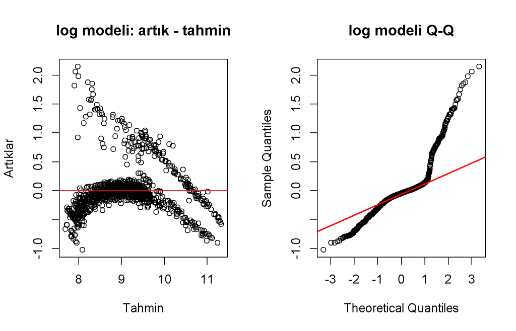

```r
artiklar2 <- residuals(model2)
par(mfrow = c(1, 2))
plot(fitted(model2), artiklar2, main = "log modeli: artık - tahmin", xlab = "Tahmin", ylab = "Artıklar")
abline(h = 0, col = "red")
qqnorm(artiklar2, main = "log modeli Q-Q"); qqline(artiklar2, col = "red", lwd = 2)
```

```r
par(mfrow = c(1, 1))

shapiro.test(artiklar2)
```

```
##
##  Shapiro-Wilk normality test
##
## data:  artiklar2
## W = 0.835, p-value < 0.00000000000000022
```

```r
bptest(model2)
```

```
##
##  studentized Breusch-Pagan test
##
## data:  model2
## BP = 54.063, df = 8, p-value = 0.000000006711
```

```r
dwtest(model2)
```

```
##
##  Durbin-Watson test
##
## data:  model2
## DW = 1.9572, p-value = 0.2411
## alternative hypothesis: true autocorrelation is greater than 0
```

**Yorum.** Düzeltilmiş R² ≈ 0,79’a yükselmiş, `sex` ve `region`’ın bazı düzeyleri anlamlı hale gelmiştir. Log modelde katsayılar yaklaşık yüzde değişim olarak yorumlanır; örneğin sigara içmek beklenen masrafı yaklaşık 365% artırır. Ancak **sorun çözülmemiştir:** Breusch-Pagan hâlâ H0’ı reddeder (BP ≈ 54, p < 0,001; değer yarıdan fazla düşmüştür ama anlamlıdır), Shapiro-Wilk W ≈ 0,84 ile normallik reddedilir (hatta kötüleşmiştir). Artık–tahmin grafiğinde eğrisel bir örüntü ve ayrı bir artık kümesi görülür; Q-Q grafiği S biçimindedir. Durbin-Watson (≈ 1,96) yine sorunsuzdur.

## 5.4 Çözüm 2: Adımsal (stepwise) değişken seçimi

```r
tam  <- lm(log(charges) ~ age + sex + bmi + children + smoker + region, data = trainset)
bos  <- lm(log(charges) ~ 1, data = trainset)
ileri <- step(bos, direction = "forward", scope = formula(tam), trace = 0)
geri  <- step(tam, direction = "backward", trace = 0)
cift  <- step(bos, direction = "both", scope = formula(tam), trace = 0)
data.frame(Yontem = c("Forward", "Backward", "Both"),
           Model = c(deparse(formula(ileri)), deparse(formula(geri)), deparse(formula(cift))),
           AIC = c(AIC(ileri), AIC(geri), AIC(cift)))
```

```
##     Yontem                                                       Model      AIC
## 1  Forward log(charges) ~ smoker + age + children + bmi + region + sex 1199.079
## 2 Backward log(charges) ~ age + sex + bmi + children + smoker + region 1199.079
## 3     Both log(charges) ~ smoker + age + children + bmi + region + sex 1199.079
```

**Yorum.** Forward, backward ve both yöntemlerinin üçü de aynı modeli (tüm değişkenler) seçer ve AIC değeri aynıdır (≈ 1199,1). AIC’ye göre hiçbir değişkeni çıkarmak modeli iyileştirmez; yani **sorun değişken seçiminden kaynaklanmıyor.**

## 5.5 Çözüm 3: Etkileşim terimi (sigara × obezite)

Artık grafikleri birbirinden ayrışmış kümeler gösteriyordu; ön incelemede de BMI’nin etkisinin sigara kullanımına bağlı olduğunu görmüştük. Bir değişkenin etkisi başka bir değişkenin düzeyine göre değişiyorsa modele **etkileşim terimi** eklenir.

BMI’yi, Dünya Sağlık Örgütü’nün obezite eşiği olan 30’a göre iki düzeyli bir değişkene (`obese`) çeviriyoruz ve `smoker * obese` etkileşimini kuruyoruz. R, `smoker * obese` yazımını `smoker + obese + smoker:obese` olarak açar. Modelde BMI yerine `obese` kullanılır (ikisini birlikte almak gereksiz çoklu bağlantı doğurur).

```r
obez_ekle <- function(x) { x$obese <- factor(ifelse(x$bmi >= 30, "yes", "no"), levels = c("no", "yes")); x }
trainset_e <- obez_ekle(trainset); testset_e <- obez_ekle(testset)

model_e <- lm(log(charges) ~ age + sex + children + region + smoker * obese, data = trainset_e)
summary(model_e)
```

```
##
## Call:
## lm(formula = log(charges) ~ age + sex + children + region + smoker *
##     obese, data = trainset_e)
##
## Residuals:
##      Min       1Q   Median       3Q      Max
## -0.90647 -0.15837 -0.04233  0.03367  2.05572
##
## Coefficients:
##                      Estimate Std. Error t value             Pr(>|t|)
## (Intercept)         7.3164644  0.0465840 157.060 < 0.0000000000000002 ***
## age                 0.0364934  0.0008772  41.601 < 0.0000000000000002 ***
## sexmale            -0.0932878  0.0246292  -3.788             0.000161 ***
## children            0.1034820  0.0102420  10.104 < 0.0000000000000002 ***
## regionnorthwest    -0.0179772  0.0348585  -0.516             0.606158
## regionsoutheast    -0.1181277  0.0345051  -3.423             0.000642 ***
## regionsouthwest    -0.1063411  0.0352530  -3.017             0.002618 **
## smokeryes           1.1894128  0.0447469  26.581 < 0.0000000000000002 ***
## obeseyes            0.0306405  0.0278784   1.099             0.271985
## smokeryes:obeseyes  0.6600728  0.0616682  10.704 < 0.0000000000000002 ***
## ---
## Signif. codes:  0 '***' 0.001 '**' 0.01 '*' 0.05 '.' 0.1 ' ' 1
##
## Residual standard error: 0.4005 on 1060 degrees of freedom
## Multiple R-squared:  0.8107, Adjusted R-squared:  0.8091
## F-statistic: 504.4 on 9 and 1060 DF,  p-value: < 0.00000000000000022
```

```r
# Etkileşimin katkısı: etkileşimsiz modelle karşılaştırma (H0: etkileşim katkı sağlamaz)
model_e0 <- lm(log(charges) ~ age + sex + children + region + smoker + obese, data = trainset_e)
anova(model_e0, model_e)
```

```
## Analysis of Variance Table
##
## Model 1: log(charges) ~ age + sex + children + region + smoker + obese
## Model 2: log(charges) ~ age + sex + children + region + smoker * obese
##   Res.Df    RSS Df Sum of Sq      F                Pr(>F)
## 1   1061 188.40
## 2   1060 170.02  1    18.376 114.57 < 0.00000000000000022 ***
## ---
## Signif. codes:  0 '***' 0.001 '**' 0.01 '*' 0.05 '.' 0.1 ' ' 1
```

```r
AIC(model2, model_e0, model_e)
```

```
##          df      AIC
## model2   10 1199.079
## model_e0 10 1198.082
## model_e  11 1090.266
```

Varsayımlar etkileşimli modelde yeniden kontrol edilir:

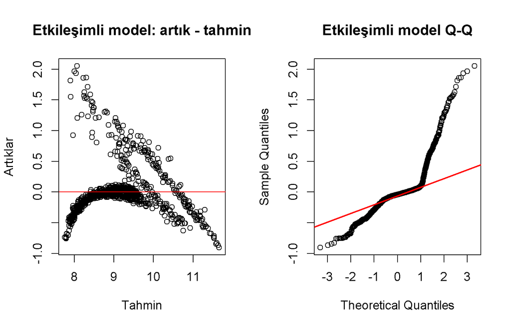

```r
artiklar_e <- residuals(model_e)
par(mfrow = c(1, 2))
plot(fitted(model_e), artiklar_e, main = "Etkileşimli model: artık - tahmin", xlab = "Tahmin", ylab = "Artıklar")
abline(h = 0, col = "red")
qqnorm(artiklar_e, main = "Etkileşimli model Q-Q"); qqline(artiklar_e, col = "red", lwd = 2)
```

```r
par(mfrow = c(1, 1))
shapiro.test(artiklar_e)
```

```
##
##  Shapiro-Wilk normality test
##
## data:  artiklar_e
## W = 0.80505, p-value < 0.00000000000000022
```

```r
bptest(model_e)
```

```
##
##  studentized Breusch-Pagan test
##
## data:  model_e
## BP = 45.774, df = 9, p-value = 0.0000006631
```

```r
dwtest(model_e)
```

```
##
##  Durbin-Watson test
##
## data:  model_e
## DW = 2.0078, p-value = 0.5493
## alternative hypothesis: true autocorrelation is greater than 0
```

```r
vif(model_e)
```

```
##                  GVIF Df GVIF^(1/(2*Df))
## age          1.012629  1        1.006295
## sex          1.011296  1        1.005632
## children     1.004909  1        1.002451
## region       1.048195  3        1.007876
## smoker       2.137150  1        1.461899
## obese        1.291829  1        1.136587
## smoker:obese 2.396267  1        1.547988
```

**Yorum.**

- **Etkileşim çok anlamlıdır.** `smoker:obese` katsayısı ≈ 0,66 (p < 0,001); etkileşimsiz modele göre karşılaştırma F testi p < 0,001’dir (H0: etkileşim katkı sağlamaz, reddedilir). AIC ≈ 1199’dan ≈ 1090’a düşmüştür (≈ 108 puanlık iyileşme; 10 puan fark çok güçlü kabul edilir). Düzeltilmiş R² ≈ 0,81’dir.
- **Yorumu:** Sigara içmeyenlerde obezite masrafı anlamlı değiştirmez (`obese` katsayısı ≈ 0,03, p ≈ 0,27). Sigara içenlerde ise obezite (ana etki + etkileşim) beklenen masrafı yaklaşık %100 artırır. Yani **obezitenin etkisi yalnızca sigara içenlerde ortaya çıkar**; etkileşim olmadan bu bilgi modelde görünmüyordu.
- **Varsayımlar:** Breusch-Pagan hâlâ H0’ı reddeder (BP ≈ 46, p < 0,001) ama log modele göre (BP ≈ 54, p ≈ 10⁻⁹) p-değeri belirgin biçimde yükselmiştir. Shapiro-Wilk (W ≈ 0,81) normalliği reddeder, normallik sorunu giderilememiştir. Artık–tahmin grafiğinde ayrışmış kümeler azalmış ama tamamen kaybolmamıştır; kalan kümelerin kaynağı bu modelde açıklanamamaktadır.
- Durbin-Watson ≈ 2,01 (otokorelasyon yok); VIF değerleri ≤ 2,4 (çoklu bağlantı yok).

## 5.6 Çözüm 4: Aykırı ve etkili gözlemler

Standartlaştırılmış artıklar, Cook uzaklığı (4/n ve 3·ortalama ölçütleri), kaldıraç (2p/n) ve DFFITS incelenir. **Hem standart artığı büyük (|r| > 2) hem de Cook uzaklığı büyük olan** gözlemler aykırı ve etkili kabul edilir.

```r
n <- nrow(trainset); p <- length(coef(model2))
dist  <- cooks.distance(model2)
sres  <- rstandard(model2)
lev   <- hatvalues(model2)
dff   <- dffits(model2)

olcut1 <- mean(dist) * 3
olcut2 <- 4 / n

c(Cook_3ort = sum(dist > olcut1), Cook_4n = sum(dist > olcut2),
  std_artik_2 = sum(abs(sres) > 2), kaldirac_2pn = sum(lev > 2 * p / n),
  DFFITS = sum(abs(dff) > 2 * sqrt(p / n)))
```

```
##    Cook_3ort      Cook_4n  std_artik_2 kaldirac_2pn       DFFITS
##          109           90           70           12           90
```

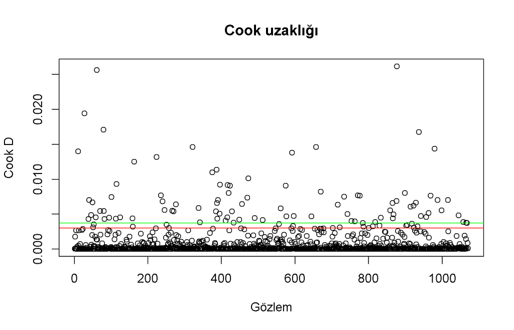

```r
plot(1:length(dist), dist, type = "p", main = "Cook uzaklığı", xlab = "Gözlem", ylab = "Cook D")
abline(h = olcut1, col = "red"); abline(h = olcut2, col = "green")
```

```r
outliers <- which(dist > olcut2 & abs(sres) > 2)
length(outliers)
```

```
## [1] 63
```

```r
trainsetrem <- if (length(outliers) > 0) trainset[-outliers, ] else trainset
c(oncesi = nrow(trainset), sonrasi = nrow(trainsetrem))
```

```
##  oncesi sonrasi
##    1070    1007
```

```r
model3 <- lm(log(charges) ~ ., data = trainsetrem)
summary(model3)
```

```
##
## Call:
## lm(formula = log(charges) ~ ., data = trainsetrem)
##
## Residuals:
##      Min       1Q   Median       3Q      Max
## -0.85020 -0.11097  0.00688  0.08985  1.01308
##
## Coefficients:
##                   Estimate Std. Error t value             Pr(>|t|)
## (Intercept)      6.7753583  0.0522224 129.740 < 0.0000000000000002 ***
## age              0.0397479  0.0006471  61.428 < 0.0000000000000002 ***
## sexmale         -0.0859214  0.0177888  -4.830   0.0000015787913998 ***
## bmi              0.0116796  0.0015366   7.601   0.0000000000000677 ***
## children         0.1153828  0.0073987  15.595 < 0.0000000000000002 ***
## smokeryes        1.5396594  0.0224957  68.442 < 0.0000000000000002 ***
## regionnorthwest -0.0735970  0.0252579  -2.914             0.003650 **
## regionsoutheast -0.1385306  0.0253959  -5.455   0.0000000618158825 ***
## regionsouthwest -0.0950416  0.0253957  -3.742             0.000193 ***
## ---
## Signif. codes:  0 '***' 0.001 '**' 0.01 '*' 0.05 '.' 0.1 ' ' 1
##
## Residual standard error: 0.2816 on 998 degrees of freedom
## Multiple R-squared:  0.9028, Adjusted R-squared:  0.9021
## F-statistic:  1159 on 8 and 998 DF,  p-value: < 0.00000000000000022
```

**Yorum.** Farklı ölçütler 12 ile 109 arasında değişen sayıda şüpheli gözlem işaretler (Cook > 3·ort: 109; Cook > 4/n: 90; |std. artık| > 2: 70; DFFITS: 90; yüksek kaldıraç: 12). Hem Cook hem standart artık ölçütünü aşan **63 gözlem** çıkarılmış, eğitim kümesi 1070’ten 1007’ye inmiştir.

Çıkarılan model (M3) eğitim verisinde çok daha iyi görünür (düzeltilmiş R² ≈ 0,90, artık std. hatası 0,42 → 0,28). **Bu tek başına bir kanıt değildir:** çıkarılan gözlemler tam da modelin kötü uydurduğu gözlemlerdir, dolayısıyla eğitim R²’sinin yükselmesi beklenir. Asıl karar, aşağıdaki test performansından verilir.

## 5.7 Çözüm 5: Ağırlıklı en küçük kareler (WLS)

Değişen varyans devam ettiğinde, gözlemlere varyanslarıyla ters orantılı ağırlık vererek model yeniden kurulur. Standart sapma, mutlak artıkların tahmin değerlerine regresyonundan elde edilir; ağırlık = 1 / (tahmini std. sapma)².

```r
yardimci <- lm(abs(residuals(model2)) ~ fitted(model2))
s_hat <- fitted(yardimci)
cat("Negatif/sıfır std. sapma tahmini sayısı:", sum(s_hat <= 0), "\n")
```

```
## Negatif/sıfır std. sapma tahmini sayısı: 0
```

```r
w <- 1 / pmax(s_hat, 1e-6)^2

model4 <- lm(log(charges) ~ ., data = trainset, weights = w)
summary(model4)
```

```
##
## Call:
## lm(formula = log(charges) ~ ., data = trainset, weights = w)
##
## Weighted Residuals:
##     Min      1Q  Median      3Q     Max
## -3.9521 -0.7012 -0.1715  0.2398  8.1356
##
## Coefficients:
##                  Estimate Std. Error t value             Pr(>|t|)
## (Intercept)      6.939659   0.076411  90.821 < 0.0000000000000002 ***
## age              0.035797   0.000924  38.741 < 0.0000000000000002 ***
## sexmale         -0.073282   0.025820  -2.838             0.004624 **
## bmi              0.013610   0.002199   6.189       0.000000000862 ***
## children         0.100623   0.010749   9.361 < 0.0000000000000002 ***
## smokeryes        1.532037   0.031994  47.885 < 0.0000000000000002 ***
## regionnorthwest -0.023764   0.036621  -0.649             0.516536
## regionsoutheast -0.132599   0.036847  -3.599             0.000335 ***
## regionsouthwest -0.092354   0.037080  -2.491             0.012903 *
## ---
## Signif. codes:  0 '***' 0.001 '**' 0.01 '*' 0.05 '.' 0.1 ' ' 1
##
## Residual standard error: 1.615 on 1061 degrees of freedom
## Multiple R-squared:  0.7908, Adjusted R-squared:  0.7892
## F-statistic: 501.4 on 8 and 1061 DF,  p-value: < 0.00000000000000022
```

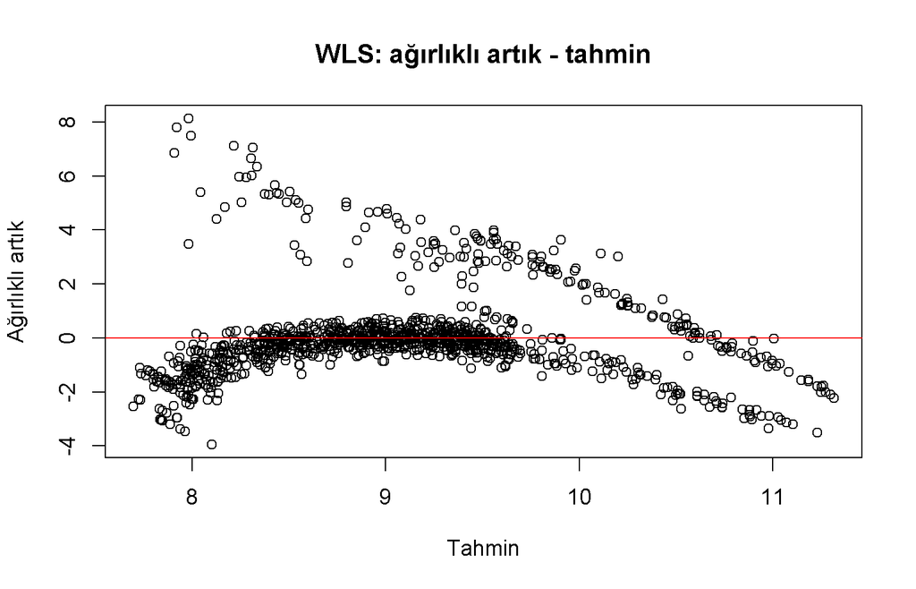

```r
# Ağırlıklı (standartlaştırılmış) artıklarla varyans ve normallik kontrolü
rw <- residuals(model4) * sqrt(w)
plot(fitted(model4), rw, main = "WLS: ağırlıklı artık - tahmin", xlab = "Tahmin", ylab = "Ağırlıklı artık")
abline(h = 0, col = "red")
```

```r
bptest(rw ~ fitted(model4))
```

```
##
##  studentized Breusch-Pagan test
##
## data:  rw ~ fitted(model4)
## BP = 4.9916, df = 1, p-value = 0.02547
```

```r
shapiro.test(rw)
```

```
##
##  Shapiro-Wilk normality test
##
## data:  rw
## W = 0.8394, p-value < 0.00000000000000022
```

**Yorum.** WLS değişen varyansı **büyük ölçüde azaltır:** ağırlıklı artıklar için Breusch-Pagan p-değeri ≈ 10⁻⁹’dan ≈ 0,025’e çıkmıştır. Yine de 0,05’in altında olduğundan sorun tam giderilmemiştir. Normallik (Shapiro-Wilk p < 0,001) ise değişmemiştir; WLS normallik sorununu çözmez. Katsayı tahminleri M2’ye çok yakın kalır.

## 5.8 Test verisinde performans karşılaştırması

Log-modellerin tahminleri `exp()` ile orijinal ölçeğe çevrilir; tüm modeller test verisinde **masraf ölçeğinde** karşılaştırılır.

```r
degerlendir <- function(m, log_model, veri = testset) {
  tahmin <- predict(m, veri)
  if (log_model) tahmin <- exp(tahmin)
  c(RMSE = RMSE(tahmin, veri$charges),
    MAE  = MAE(tahmin, veri$charges),
    R2   = R2(tahmin, veri$charges))
}
sonuc <- rbind(
  "M1: charges ~ . (ham)"                  = degerlendir(model1, FALSE),
  "M2: log(charges) ~ ."                   = degerlendir(model2, TRUE),
  "M3: M2, aykırı/etkili çıkarıldı"        = degerlendir(model3, TRUE),
  "M4: M2, WLS"                            = degerlendir(model4, TRUE),
  "M5: log, smoker × obese etkileşimi"     = degerlendir(model_e, TRUE, testset_e)
)
round(sonuc, 3)
```

```
##                                        RMSE      MAE    R2
## M1: charges ~ . (ham)              6918.289 4691.265 0.704
## M2: log(charges) ~ .               9078.695 4697.327 0.585
## M3: M2, aykırı/etkili çıkarıldı    9476.383 4834.999 0.556
## M4: M2, WLS                        9010.295 4675.758 0.588
## M5: log, smoker × obese etkileşimi 9138.220 4593.764 0.655
```

**Yorum.**

- **RMSE ve R²:** Ham ölçekte kurulan **M1 en iyisidir** (RMSE ≈ 6.900, R² ≈ 0,70). Log modeller (M2–M4) çok yüksek masrafları (sigara içenler) hafife aldığı için kare hatası büyür (RMSE ≈ 9.000–9.500).
- **MAE:** M1–M4 ≈ 4.700 civarındadır. **Etkileşimli model (M5) en düşük MAE’ye sahiptir (≈ 4.590)** ve log modeller arasında en yüksek test R²’ye ulaşır (≈ 0,655; M2 için 0,585). Etkileşim, tipik bir müşteri için tahmini iyileştirir.
- **Aykırı/etkili gözlemleri çıkarmak (M3) test performansını kötüleştirmiştir** (RMSE 9.079 → 9.476, R² 0,585 → 0,556). Genel ilke olarak çıkarma sonrası performans düşüyorsa bu gözlemler gürültü değil, **etkili ama geçerli** gözlemlerdir ve modelde kalmalıdır.
- **WLS (M4)**, M2’ye göre sadece çok küçük bir iyileşme sağlar (RMSE 9.079 → 9.010).
- Log dönüşümü varsayımlar açısından (BP istatistiği) bir miktar fayda sağlamasına rağmen, **RMSE açısından bu veride avantaj getirmemiştir.** Log modeller içinde asıl iyileşme etkileşim terimiyle gelmiştir.

## 5.9 Temel bileşenler regresyonu (PCR)

PCR çoklu bağlantı sorununa çözümdür. Bu veride VIF değerleri ≈ 1 olduğundan, gerçekten gerekli olup olmadığı çapraz doğrulama ile sınanır (yalnızca sayısal değişkenlerle).

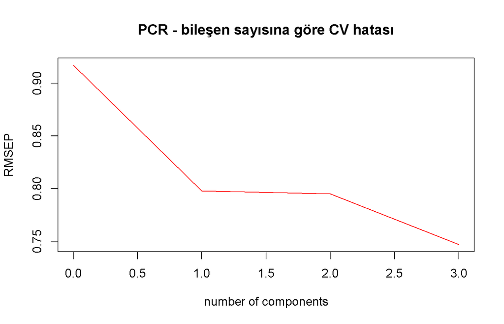

```r
set.seed(123)
pcr_m <- pcr(log(charges) ~ age + bmi + children, data = trainset, scale = TRUE, validation = "CV")
pcrCV <- RMSEP(pcr_m, estimate = "CV")
plot(pcrCV, main = "PCR - bileşen sayısına göre CV hatası", col = "red")
```

```r
pcrCV$val[1, 1, ]
```

```
## (Intercept)     1 comps     2 comps     3 comps
##   0.9170746   0.7977908   0.7948771   0.7467989
```

```r
which.min(pcrCV$val[1, 1, ]) - 1
```

```
## 3 comps
##       3
```

**Yorum.** Çapraz doğrulama hatası bileşen sayısı arttıkça düşer (0,917 → 0,798 → 0,795 → 0,747) ve en küçük değere **tüm bileşenler** (3) kullanıldığında ulaşır. Bileşen atmanın kazancı yoktur; çoklu bağlantı olmayan bu veride **PCR gereksizdir.**

## 5.10 K-katlı çapraz doğrulama ile kararlılık kontrolü

Tek bir eğitim/test bölünmesi şansa bağlı olabilir. Tüm veri 10 parçaya bölünür; her parça sırayla test, kalanı eğitim olarak kullanılır ve hata ölçütlerinin ortalaması ile standart sapması alınır.

```r
set.seed(145)
katlar <- createFolds(d$charges, k = 10)
cv_sonuc <- t(sapply(katlar, function(ix) {
  tr <- obez_ekle(d[-ix, ]); te <- obez_ekle(d[ix, ])
  a <- lm(charges ~ age + sex + bmi + children + smoker + region, tr)
  b <- lm(log(charges) ~ age + sex + bmi + children + smoker + region, tr)
  e <- lm(log(charges) ~ age + sex + children + region + smoker * obese, tr)
  pa <- predict(a, te); pb <- exp(predict(b, te)); pe <- exp(predict(e, te))
  c(M1_RMSE = RMSE(pa, te$charges), M2_RMSE = RMSE(pb, te$charges), M5_RMSE = RMSE(pe, te$charges),
    M1_MAE  = MAE(pa, te$charges),  M2_MAE  = MAE(pb, te$charges),  M5_MAE  = MAE(pe, te$charges))
}))
data.frame(Olcut = colnames(cv_sonuc),
           Ortalama = round(colMeans(cv_sonuc)),
           Std_Sapma = round(apply(cv_sonuc, 2, sd)))
```

```
##           Olcut Ortalama Std_Sapma
## M1_RMSE M1_RMSE     6070       526
## M2_RMSE M2_RMSE     8398       781
## M5_RMSE M5_RMSE     8729      1543
## M1_MAE   M1_MAE     4203       258
## M2_MAE   M2_MAE     4252       441
## M5_MAE   M5_MAE     4113       622
```

**Yorum.** 10 katın ortalamasında ham model (M1) RMSE ≈ 6.070 (± 526) iken log model (M2) ≈ 8.400 (± 780) ve etkileşimli log model (M5) ≈ 8.730 (± 1.540)’dir; ham ve log modeller arasındaki fark standart sapmalardan çok büyüktür, yani **tek bölünmedeki sıralama şansa bağlı değildir.** M5’in RMSE’si kattan kata çok dalgalıdır (yüksek standart sapma): modelin çok yüksek masraflı birkaç gözlemi tahmin etmedeki başarısı bölünmeye duyarlıdır. MAE’de M5 en düşük ortalamaya sahiptir (≈ 4.110; M1 ≈ 4.200, M2 ≈ 4.250), ancak aradaki fark standart sapmaların (≈ 260–620) içindedir, yani **MAE açısından üç model istatistiksel olarak ayırt edilemez.**

# 6 Sonuç

**Doğrusal regresyon**

- Masrafı açıklayan temel değişkenler **sigara, yaş, çocuk sayısı ve BMI’dir**; sigara açık ara en güçlüsüdür. Cinsiyet ve bölge etkisi küçüktür.
- **En önemli bulgu etkileşimdir:** obezitenin masrafa etkisi yalnızca sigara içenlerde ortaya çıkar (sigara × obezite). Etkileşim modele eklendiğinde AIC ≈ 108 puan düşmüş, düzeltilmiş R² ≈ 0,81’e yükselmiş, test MAE ve R² iyileşmiştir.
- Çoklu bağlantı ve otokorelasyon sorunu yoktur. **Normallik ve sabit varyans varsayımları sağlanmamaktadır;** log dönüşümü, adımsal seçim, etkileşim, aykırı gözlem çıkarma ve WLS bu sorunu tam gidermemiştir (etkileşim ve WLS değişen varyansı belirgin biçimde azaltmıştır).
- Aykırı/etkili gözlemleri çıkarmak test performansını kötüleştirmiştir; bu gözlemler geçerlidir.
- Test ve 10 katlı çapraz doğrulamada ham ölçekli model RMSE bakımından en iyidir; MAE bakımından etkileşimli model en düşük ortalamaya sahiptir ancak fark çapraz doğrulama standart sapmaları içindedir. Varsayım ihlalleri nedeniyle **p-değerleri ve güven aralıkları dikkatle yorumlanmalıdır.**
- PCR gereksizdir (çoklu bağlantı yoktur).

**Sınırlılıklar**

- Veri eğitim amaçlı, büyük olasılıkla simüle edilmiş bir veridir; sonuçlar gerçek bir sigorta portföyüne genellenemez.
- Doğrusal modellerde normallik ve sabit varyans varsayımları tam sağlanamamıştır; artık grafiklerindeki kalan kümelerin kaynağı belirlenememiştir.
- Obezite eşiği (BMI ≥ 30) dışarıdan alınmış bir kestirimdir; BMI sürekli bırakılıp etkileşim kurulduğunda sonuçlar değişebilir.

# 7 Tekrarlanabilirlik